# Описание линейных моделей, проверка их значимости и валидности

Линейные модели…

Вадим Хайтов, Анастасия Лянгузова, Наталья Арбузова, Валентина Домашкина, Юта Тамберг, Марина Варфоломеева

Кафедра Зоологии беспозвоночных, СПбГУ

## Описание и проверка значимости линейных моделей

## Вы сможете

- Подобрать линейную модель зависимости переменной-отклика от одного предиктора
- Протестировать значимость линейной модели в целом и значимость отдельных ее коэффициентов при помощи t и F критериев
- Проверить условия применимости линейной регрессии при помощи графиков

## Вспомним пример из прошлой лекции

## Пример: IQ и размеры мозга

Зависит ли уровень интеллекта от размера головного мозга? (Willerman et al. 1991)

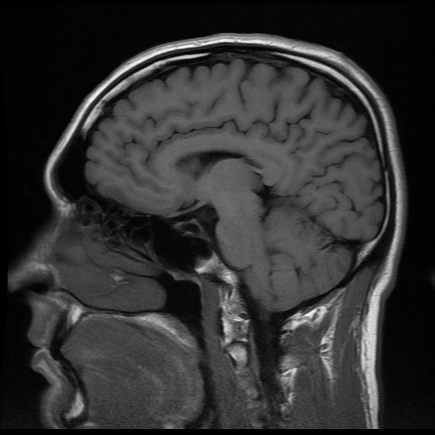

Scan_03_11

[Scan_03_11](https://flic.kr/p/c45eZ3) by bucaorg(Paul_Burnett) on Flickr

Было исследовано 20 девушек и 20 молодых людей

У каждого индивида измеряли:

- вес
- рост
- размер головного мозга (количество пикселей на изображении ЯМР сканера)
- Уровень интеллекта измеряли с помощью IQ тестов

Пример: Willerman, L., Schultz, R., Rutledge, J. N., and Bigler, E. (1991), “In Vivo Brain Size and Intelligence”, Intelligence, 15, p.223–228.  
Данные: [“The Data and Story Library”](http://lib.stat.cmu.edu/DASL)  
Фото: [Scan_03_11](https://flic.kr/p/c45eZ3) by bucaorg (Paul Burnett) on Flickr

## Вспомним, на чем мы остановились

```r
brain_model <- lm(PIQ ~ MRINACount, data = brain)
summary(brain_model)
```

```
Call:
lm(formula = PIQ ~ MRINACount, data = brain)

Residuals:
    Min      1Q  Median      3Q     Max
-39.582 -17.953  -1.601  17.027  42.262

Coefficients:
             Estimate Std. Error t value Pr(>|t|)
(Intercept) 1.744e+00  4.239e+01   0.041   0.9674
MRINACount  1.202e-04  4.651e-05   2.586   0.0137 *
---
Signif. codes:  0 '***' 0.001 '**' 0.01 '*' 0.05 '.' 0.1 ' ' 1

Residual standard error: 20.99 on 38 degrees of freedom
Multiple R-squared:  0.1496,    Adjusted R-squared:  0.1272
F-statistic: 6.686 on 1 and 38 DF,  p-value: 0.01367
```

## Уравнение и график зависимости

$$PIQ_i = 1.744 + 0.0001202 \cdot MRINACount_i$$

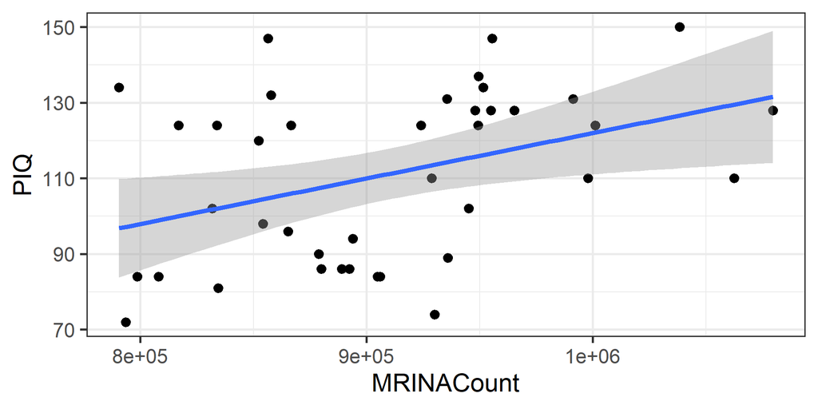

## Тестирование гипотез о линейных моделях

## Способы проверки значимости модели и ее коэффициентов

Два равноправных способа

**Значима ли модель целиком?**

- F критерий

**Значима ли связь между предиктором и откликом?**

- t-критерий
- F-критерий

## Тестирование гипотез с помощью t-критерия

## Тестирование гипотез с помощью t-критерия

### Гипотезы

Зависимость есть, если угловой коэффициент $\beta_k \ne 0$

Нулевая гипотеза $H_0: \beta_k = 0$

## Тестирование гипотез с помощью t-критерия

### Гипотезы

Зависимость есть, если угловой коэффициент $\beta_k \ne 0$

Нулевая гипотеза $H_0: \beta_k = 0$

### Тестовая статистика

$$t=\frac{b_k - \beta_k}{SE_{b_k}} = \frac{b_k - 0}{SE_{b_k}} = \frac{b_k}{SE_{b_k}}$$

При соблюдении условий применимости, t-статистика должна подчиняться t-распределению с параметром $df$

Число степеней свободы: $df = n − p$,

где

$n$ — объем выборки,  
$p$ — число параметров модели,  
$b_k$ — конкретный коэффициент регрессии.

Для простой линейной регрессии с одним предиктором $df = n - 2$.

## Зависит ли IQ от размера головного мозга?

$$PIQ_i = 1.744 + 0.0001202 \cdot MRINACount_i$$

```
Call:
lm(formula = PIQ ~ MRINACount, data = brain)

Residuals:
    Min      1Q  Median      3Q     Max
-39.582 -17.953  -1.601  17.027  42.262

Coefficients:
             Estimate Std. Error t value Pr(>|t|)
(Intercept) 1.744e+00  4.239e+01   0.041   0.9674
MRINACount  1.202e-04  4.651e-05   2.586   0.0137 *
---
Signif. codes:  0 '***' 0.001 '**' 0.01 '*' 0.05 '.' 0.1 ' ' 1

Residual standard error: 20.99 on 38 degrees of freedom
Multiple R-squared:  0.1496,    Adjusted R-squared:  0.1272
F-statistic: 6.686 on 1 and 38 DF,  p-value: 0.01367
```

Результаты теста на IQ статистически значимо связаны  
с размерами мозга на МРТ ( $t_{ 0.05, 38}$ = 2.59, $p$ = 0.014 ).

## Тестирование гипотез при помощи F-критерия

## Общая изменчивость

Общая изменчивость $SS_{t}$ — это сумма квадратов отклонений наблюдаемых значений $y_i$ от общего среднего $\bar y$

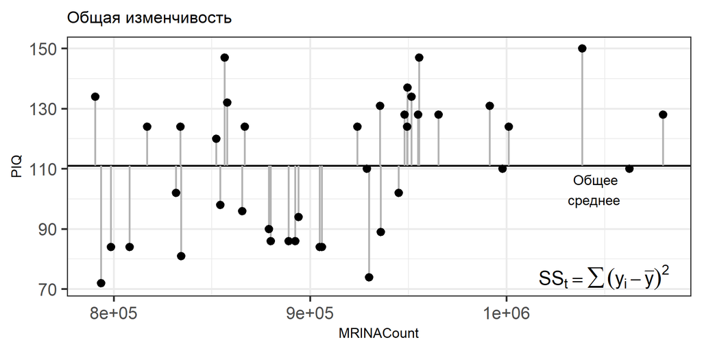

## Структура общей изменчивости

$$SS_t = \color{blue}{SS_r} + \color{green}{SS_e}$$
Общую изменчивость зависимой переменной можно разложить на две составляющие:

$\color{blue}{SS_r}$ - отклонения предсказанных значений от общего среднего (*Объясненная изменчивость*)

$\color{green}{SS_e}$ - отклонения наблюдаемых значений от предсказанных (*Остаточная изменчивость*)

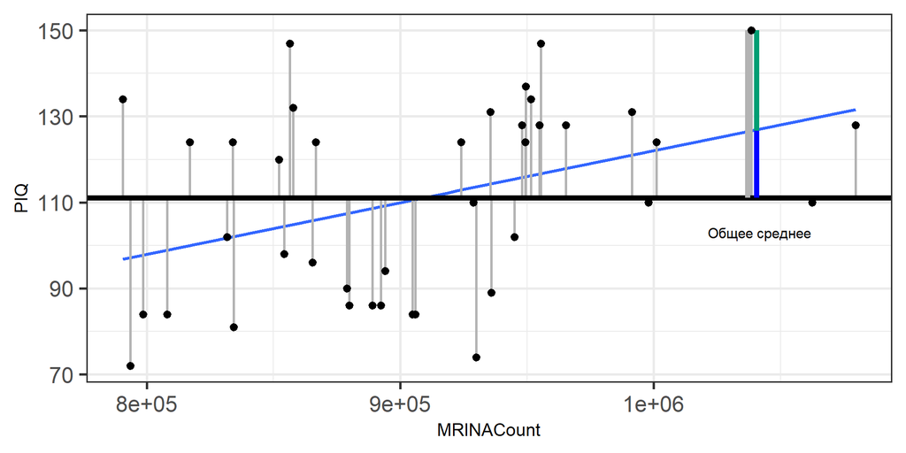

## Общая изменчивость

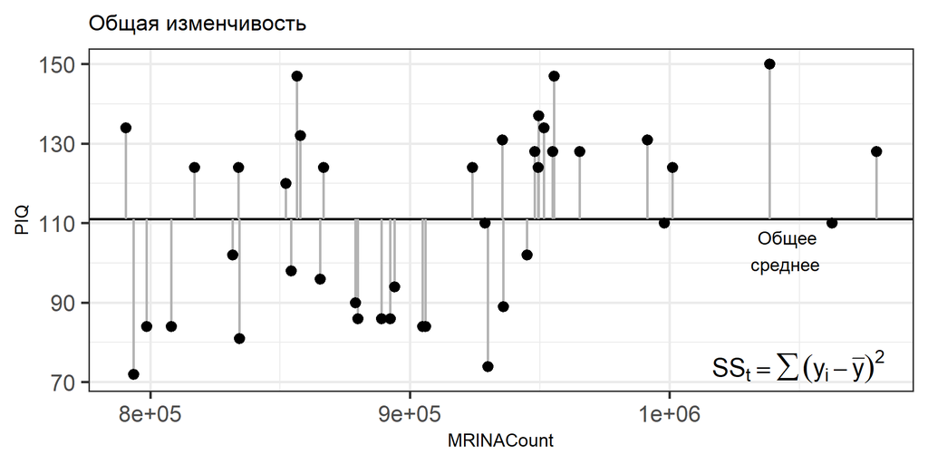

## Объясненная изменчивость

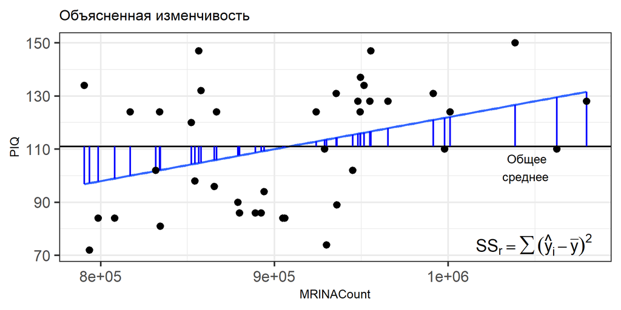

## Случайная (остаточная) изменчивость

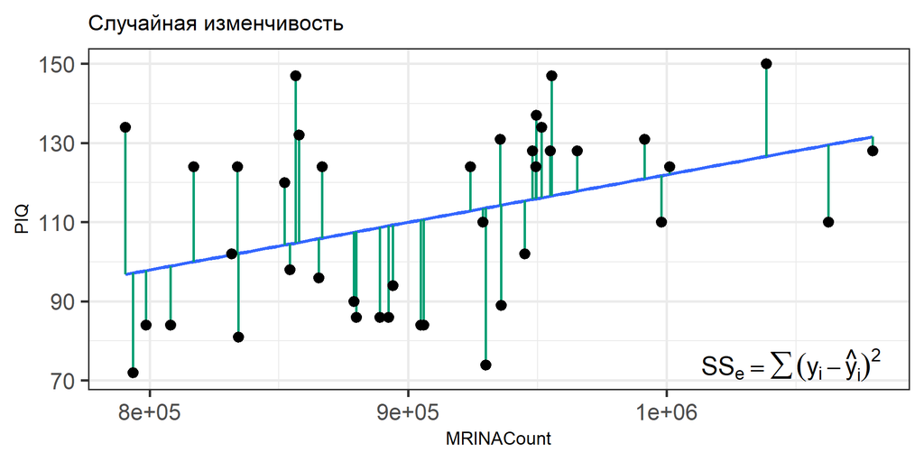

## Все изменчивости

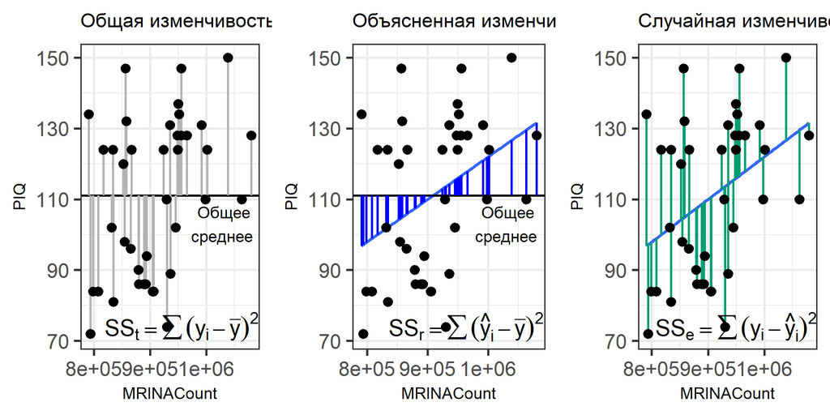

## От сумм квадратов к дисперсиям

| $MS_t$, полная дисперсия | $\color{blue}{MS_r}$, дисперсия, объясненная регрессией | $\color{green}{MS_e}$, остаточная дисперсия |
| --- | --- | --- |
| $MS_{t} =\frac{SS_{t}}{df_{t}}$ | $\color{blue}{MS_{r}} =\frac{\color{blue}{SS_{r}}}{df_{r}}$ | $\color{green}{MS_{e}} =\frac{\color{green}{SS_{e}}}{df_{e}}$ |
| $SS_{t}=\sum{(y_i - \bar{y})^2}$ | $\color{blue}{SS_{r}}=\sum{(\hat{y}-\bar{y})^2}$ | $\color{green}{SS_{e}}=\sum{(y_i - \hat{y})^2}$ |
| $df_{t} = n-1$ | $df_{r} = 1$ | $df_{e} = n-2$ |

## С помощью $MS_r$ и $MS_e$ можно тестировать значимость коэффициентов

Если дисперсии остатков для всех значений x равны, то

$E(\color{blue}{MS_r}) = \color{green}{\sigma^2} + \color{red}{\beta_1}^2\sum(x_i - \bar x)^2 =$

$= \color{green}{\sigma^2} + \sigma_{x}^2$

$E(\color{green}{MS_e}) = \color{green}{\sigma^2}$

Если зависимости нет, то $\color{red}{\beta_1} = 0$, и тогда

$\color{blue}{MS_r} \approx \color{green}{MS_e}$

Мы хотим протестировать гипотезы:

- $H_0: \color{red}{\beta_1} = 0$
- $H_A: \color{red}{\beta_1} \ne 0$

Если справедлива $H_A: \color{red}{\beta_1} \ne 0$, то $\color{blue}{MS_r} > \color{green}{MS_e}$

$$F= \frac{\color{blue}{MS _{r}}}{\color{green}{MS_{e}}}$$
. . .

Поздравляю, вы только что изобрели *F*-критерий!

## Тестирование значимости коэффициентов регрессии при помощи F-критерия

- $H_0: \color{red}{\beta_1} = 0$
- $H_A: \color{red}{\beta_1} \ne 0$

$$F_{df_r, df_e}= \frac{\color{blue}{MS _{r}}}{\color{green}{MS_{e}}}$$

Для простой линейной регрессии  
$df_{r} = 1$ и $df_{e} = n - 2$

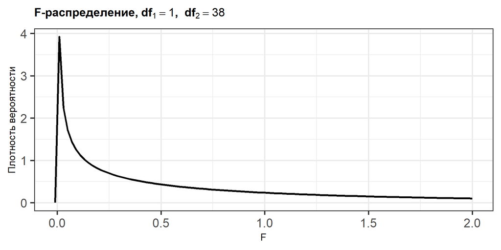

- У F-распределения два параметра: $df_{r}$ и $df_{e}$
- Логика F-теста аналогична t-критерию: Определяем вероятность того, что при *условии справедливости $H_0$* при повторных выборках появится значение F больше или равное F, полученному в нашем эксперименте.
- F-тест будет односторонним, т.к. соотношение дисперсий может быть только положительным.

## Таблица результатов дисперсионного анализа

| Источник изменчивости | df | SS | MS | F |
| --- | --- | --- | --- | --- |
| Регрессия | $df _r = 1$ | $\color{blue}{SS _r} = \sum{(\hat y _i - \bar y)^2}$ | $\color{blue}{MS _r} = \frac{\color{blue}{SS _r}}{df _r}$ | $F _{df _r, df _e} = \frac{\color{blue}{MS _r}}{\color{green}{MS _e}}$ |
| Остаточная | $df _e = n - 2$ | $\color{green}{SS _e} = \sum{(y _i - \hat y _i)^2}$ | $\color{green}{MS _e} = \frac{\color{green}{SS _e}}{df _e}$ |  |
| Общая | $df _t = n - 1$ | $SS _t = \sum {(y _i - \bar y)^2}$ |  |  |

Минимальное упоминание результатов в тексте должно содержать $F _{df _r, df _e}$ и $p$.

## Посмотрим на `summary()`

```r
summary(brain_model)
```

```
Call:
lm(formula = PIQ ~ MRINACount, data = brain)

Residuals:
    Min      1Q  Median      3Q     Max
-39.582 -17.953  -1.601  17.027  42.262

Coefficients:
             Estimate Std. Error t value Pr(>|t|)
(Intercept) 1.744e+00  4.239e+01   0.041   0.9674
MRINACount  1.202e-04  4.651e-05   2.586   0.0137 *
---
Signif. codes:  0 '***' 0.001 '**' 0.01 '*' 0.05 '.' 0.1 ' ' 1

Residual standard error: 20.99 on 38 degrees of freedom
Multiple R-squared:  0.1496,    Adjusted R-squared:  0.1272
F-statistic: 6.686 on 1 and 38 DF,  p-value: 0.01367
```

С помощью F-критерия мы показали, что модель целиком значима.

## Дисперсионный анализ модели `anova()`

```
Analysis of Variance Table

Response: PIQ
           Df  Sum Sq Mean Sq F value  Pr(>F)
MRINACount  1  2946.6 2946.61  6.6863 0.01367 *
Residuals  38 16746.4  440.69
---
Signif. codes:  0 '***' 0.001 '**' 0.01 '*' 0.05 '.' 0.1 ' ' 1
```

С помощью F-критерия мы показали, что влияние предиктора значимо!

## Оценка качества подгонки модели

## В чем различие между этими двумя моделями?

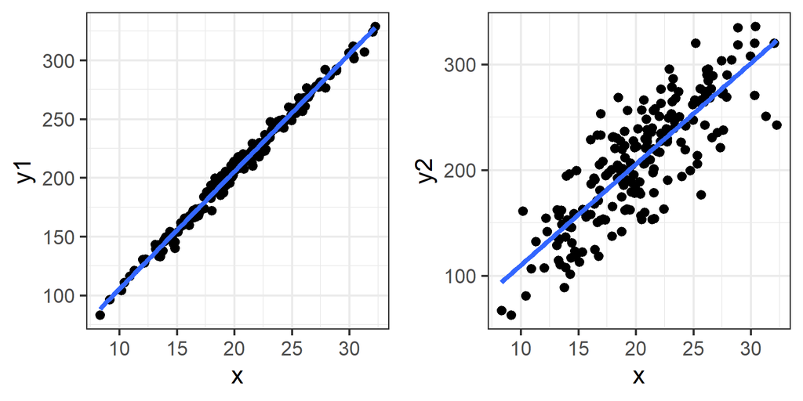

–

У этих моделей разный разброс остатков:

- Модель слева объясняет практически всю изменчивость
- Модель справа объясняет не очень много изменчивости

## Коэффициент детерминации — мера качества подгонки модели

**Коэффициент детерминации** описывает какую долю дисперсии зависимой переменной объясняет модель

$$R^2 = \frac{\color{blue}{SS_{r}}}{SS_{t}}$$

- $0 < R^2 < 1$
- $R^2 = r^2$ — для простой линейной регрессии коэффициент детерминации равен квадрату коэффициента Пирсоновской корреляции

## Если в модели много предикторов, нужно внести поправку

**Скорректированный коэффициет детерминации** (adjusted R-squared)

Применяется если необходимо сравнить две модели с разным количеством параметров

$$R^2_{adj} = 1- (1-R^2)\frac{n-1}{n-p}$$

$p$ - количество параметров в модели

Вводится штраф за каждый новый параметр

## Еще раз смотрим на результаты регрессионного анализа зависимости IQ от размеров мозга

```
Call:
lm(formula = PIQ ~ MRINACount, data = brain)

Residuals:
    Min      1Q  Median      3Q     Max
-39.582 -17.953  -1.601  17.027  42.262

Coefficients:
             Estimate Std. Error t value Pr(>|t|)
(Intercept) 1.744e+00  4.239e+01   0.041   0.9674
MRINACount  1.202e-04  4.651e-05   2.586   0.0137 *
---
Signif. codes:  0 '***' 0.001 '**' 0.01 '*' 0.05 '.' 0.1 ' ' 1

Residual standard error: 20.99 on 38 degrees of freedom
Multiple R-squared:  0.1496,    Adjusted R-squared:  0.1272
F-statistic: 6.686 on 1 and 38 DF,  p-value: 0.01367
```

Модель зависимости IQ от размеров мозга на МРТ объясняет всего лишь 15 % общей изменчивости IQ в этих данных.

Ценность такой модели сомнительна.

## Как записываются результаты регрессионного анализа в тексте статьи?

Мы показали, что связь между результатами теста на IQ и размером головного мозга на МРТ описывается моделью вида  
IQ = 1.74 + 0.00012 MRINACount ( $F_{1,38}$ = 6.686, p = 0.014, $R^2$ = 0.15)

Пишем статью?

## Задание 1 & 2

Выполните задания 1 и 2 в одном из этих файлов:

- 07_task_assumptions_catsM.R
- 07_task_assumptions_GAG.R

## Зачем нужна диагностика линейных моделей

## Если стохастическая модель адекватна, то что мы можем сказать про остатки?

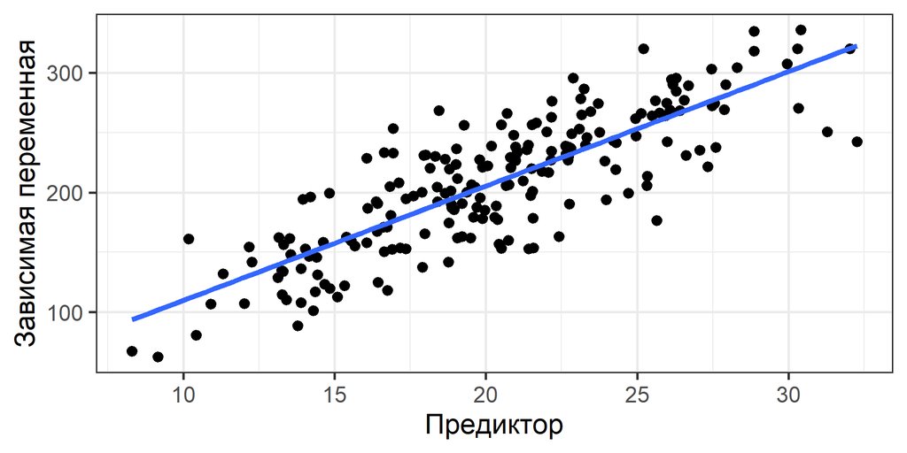

–

- Остатки — это просто шум. Обычно считается, что $\varepsilon_i \in N(0, \sigma)$.
- В остатках не должно быть никаких закономерностей (паттернов).

## Зачем нужна диагностика модели? Разве тестов было недостаточно?

Пусть у нас есть некоторая модель, которая показывает зависимость $V_1 = f(V_2, V_3, V_4, V_5)$

```r
dat <- read.table('data/orly_owl_Lin_4p_5_flat.txt')
fit <- lm(V1 ~ V2 + V3 + V4 + V5, data = dat)
summary(fit)
```

```
Call:
lm(formula = V1 ~ V2 + V3 + V4 + V5, data = dat)

Residuals:
    Min      1Q  Median      3Q     Max
-2.0652 -0.9878  0.1419  0.7958  1.9560

Coefficients:
            Estimate Std. Error t value Pr(>|t|)
(Intercept) 0.001194   0.021170   0.056    0.955
V2          0.986328   0.128630   7.668 2.56e-14 ***
V3          0.972295   0.127506   7.625 3.54e-14 ***
V4          0.861429   0.120431   7.153 1.14e-12 ***
V5          0.927474   0.084432  10.985  < 2e-16 ***
---
Signif. codes:  0 '***' 0.001 '**' 0.01 '*' 0.05 '.' 0.1 ' ' 1

Residual standard error: 1.001 on 2293 degrees of freedom
Multiple R-squared:   0.05, Adjusted R-squared:  0.04834
F-statistic: 30.17 on 4 and 2293 DF,  p-value: < 2.2e-16
```

Все значимо!

Пишем статью?

## Остатки модели

Постройте график зависимости остатков от предсказанных значений при помощи этого кода

```r
library(car)
residualPlot(fit, pch = ".")
```

## Oh, really?

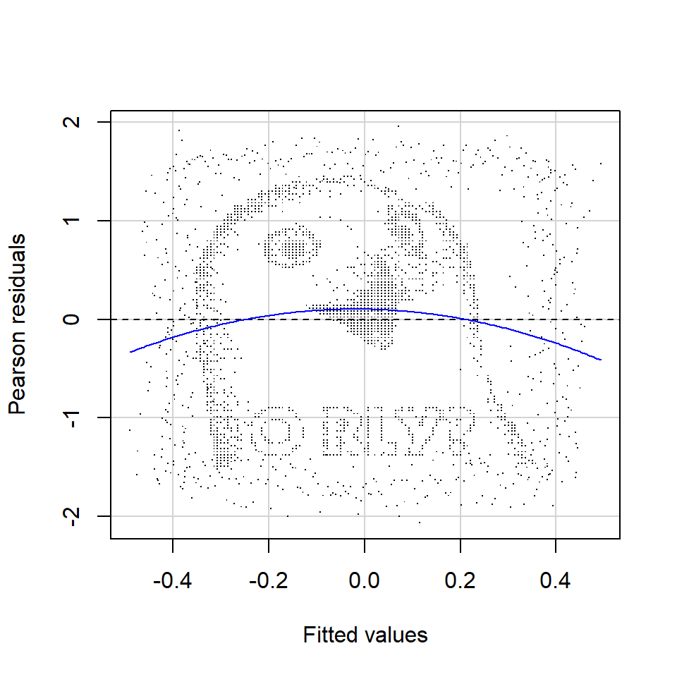

http://www4.stat.ncsu.edu/~stefanski/NSF_Supported/Hidden_Images/stat_res_plots.html

В остатках скрыта информация!

## Анализ остатков

## Анализ остатков линейных моделей

Этот анализ дает возможность:

1. Проверить данные на наличие влиятельных наблюдений и выявить их;
2. Проверить соответствует ли построенная модель условиям применимости линейных моделей.

## Условия применимости линейных моделей

1. Линейная связь
2. Независимость наблюдений
3. Соответствие нормальному распределению
4. Гомогенность дисперсий
5. Отсутствие коллинеарности предикторов (для множественной регрессии)

## Какие бывают остатки?

### “Сырые” остатки

$$\color{green}{e_i} = y_i - \color{blue}{\hat{y_i}}$$

### Стандартизованные (стьюдентизированные) остатки

$$s_i = \frac{\color{green}{e_i}}{\sqrt{MS_e(1-\color{purple}{h_{ii}})}}$$

- легко сравнивать (стандартизованы), учитывают силу влияния наблюдений
- $\sqrt{MS_e}$ — стандартное отклонение остатков
- $\color{purple}{h_{ii}}$ — “сила воздействия” отдельных наблюдений (leverage, рычаг проекционной матрицы)

## Что такое проекционная матрица?

По определению, остатки $\color{green}{\mathbf{e}} = \mathbf{y} - \color{blue}{\hat{\mathbf{y}}}$.

Тогда $\color{green}{\mathbf{e}} = \mathbf{y} - \mathbf{X} \mathbf{\beta} = \mathbf{y} - \mathbf{X}[\mathbf{X}'\mathbf{X}]^{-1}\mathbf{X}'\mathbf{y}$.

Обозначим $\color{purple}{\mathbf{H}} \equiv \mathbf{X}[\mathbf{X}'\mathbf{X}]^{-1}\mathbf{X}'$.

Матрица $\color{purple}{\mathbf{H}}$ — называется **“хэт”-матрица** (*hat-matrix*) или **проекционная матрица**, т.к. она позволяет получить предсказанные значения из наблюдаемых.

$\color{blue}{\hat{\mathbf{y}}} = \color{purple}{\mathbf{H}}\mathbf{y}$

Тогда остатки можно получить как $\color{green}{\mathbf{e}} = \mathbf{y} - \color{purple}{\mathbf{H}}\mathbf{y} = (\mathbf{I} - \color{purple}{\mathbf{H}})\mathbf{y}$.

Диагональные элементы проекционной матрицы $\color{purple}{h_{ii}}$ — это мера **воздействия** точек на ход линии регрессии.

## Влиятельные наблюдения

## Влиятельные наблюдения (influential points)

Влиятельные наблюдения — это наблюдения, которые вносят слишком большой вклад в оценку параметров (коэффициентов) модели.

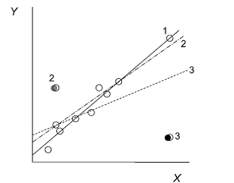

Из кн. Quinn, Keough, 2002

Учет каких из этих точек повлияет на ход регрессии и почему?

- Точка 1 почти не повлияет, т.к. у нее маленький остаток, хоть и экстремальное значение $X$
- Точка 2 почти не повлияет, т.к. ее $X$ близок к среднему, хоть и большой остаток
- Точка 3 повлияет сильно, т.к. у нее не только большой остаток, но и экстремальное значение $X$

## Воздействие точек (leverage)

**Воздействие** точек $\color{purple}{h_{ii}}$ (*leverage*) показывает силу влияния значений $x_i$ на ход линии регрессии, то есть на $\color{blue}{\hat{y_i}}$

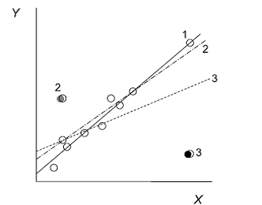

Из кн. Quinn, Keough, 2002

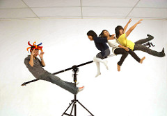

Weighing Machine by neys fadzil on Flickr

Точки, располагающиеся дальше от $\bar{x}$, оказывают более сильное влияние на $\color{blue}{\hat{y_i}}$

- $\color{purple}{h_{ii}}$ варьирует в промежутке от $1/n$ до 1
- Если $\color{purple}{h_{ii}} > 2(p/n)$, то надо внимательно посмотреть на данное значение ($p$ — число параметров модели, $n$ — объем выборки)

## Расстояние Кука (Cook’s distance)

описывает, как повлияет на модель удаление данного наблюдения

$$D_i = \frac{\sum{( \color{blue}{\hat{y_{j}}} - \color{red}{\hat{y}_{j(i)}})^2}}{p \; MS_e}$$

- $\color{blue}{\hat{y_j}}$ — значение предсказанное полной моделью
- $\color{red}{\hat{y}_{j(i)}}$ — значение, предсказанное моделью, построенной без учета $i$-го значения предиктора
- $p$ — количество параметров в модели
- $MS_{e}$ — среднеквадратичная ошибка модели ( $\hat\sigma^2$ )

## Расстояние Кука покажет оба аспекта влиятельности

Формулу расстояния Кука для данного $i$-того наблюдения можно расписать:

$$D_i = \frac{\color{green}{e_i}^2}{p \; MS_e} \cdot \frac { \color{purple}{h_{ii}} } {(1 - \color{purple}{h_{ii}}) ^ 2}$$

Видно, что $D_i$ зависит сразу от

- $\color{green}{e_i}$ — это величина остатков
- $\color{purple}{h_{ii}}$ — это воздействие наблюдений

При каком значении $D_i$ будем считать наблюдение выбросом?

Два варианта:

- $D_i > 1$ — “мягкий” порог (для простоты в этом курсе такой)
- $D_i > \frac{4}{(n - p)}$ — “жесткий” порог ( $n$ — объем выборки, $p$ — число параметров)

## Что делать с наблюдениями-выбросами?

- Удалить?

**Осторожно!** Только очевидные ошибки в наблюдениях можно удалять. Лучше найти причины.

- Трансформировать? Это не всегда поможет.
- Иногда можно переформулировать модель.

## Некоторые виды трансформаций

| Трансформация | Формула |
| --- | --- |
| степень -2 | $1/x^2$ |
| степень -1 | $1/x$ |
| степень -0.5 | $1/\sqrt{x}$ |
| степень 0.5 | $\sqrt{x}$ |
| логарифмирование | $log(x)$ |

## Данные для анализа остатков

```r
library(ggplot2)
brain_diag <- fortify(brain_model)
head(brain_diag, 2)
```

```
  PIQ MRINACount       .hat   .sigma      .cooksd   .fitted    .resid
1 124     816932 0.06637876 20.87837 0.0498380059  99.98294 24.017065
2 124    1001121 0.06686959 21.27213 0.0003039221 122.13236  1.867637
   .stdresid
1 1.18403934
2 0.09209859
```

- `.hat` — “сила воздействия” данного наблюдения (leverage)
- `.cooksd` — расстояние Кука
- `.fitted` — предсказанные значения
- `.resid` — остатки
- `.stdresid` — стандартизованные остатки

## График расстояния Кука

Проверяем наличие влиятельных наблюдений в `brain_model`.

Порядок значений на графике такой же как в исходных данных.

```r
cook_cutoff <- 4 / (nrow(brain) - length(coef(brain_model)))
```

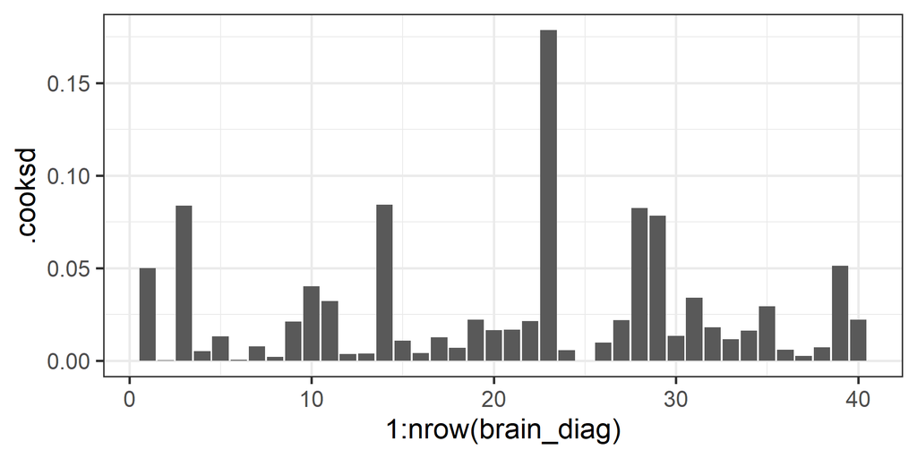

- Есть одно влиятельное наблюдение, которое нужно проверить, но сила его влияния невелика (расстояние Кука $< 1$, и только одно наблюдение больше $4/(n-p) = 0.11$)

## График остатков от предсказанных значений

Большую часть того, что нужно знать про остатки вы увидите на этом графике. А сейчас давайте научимся читать такой график.

```r
gg_resid <- ggplot(data = brain_diag, aes(x = .fitted, y = .stdresid)) +
  geom_point() +
  geom_hline(yintercept = 0)
gg_resid
```

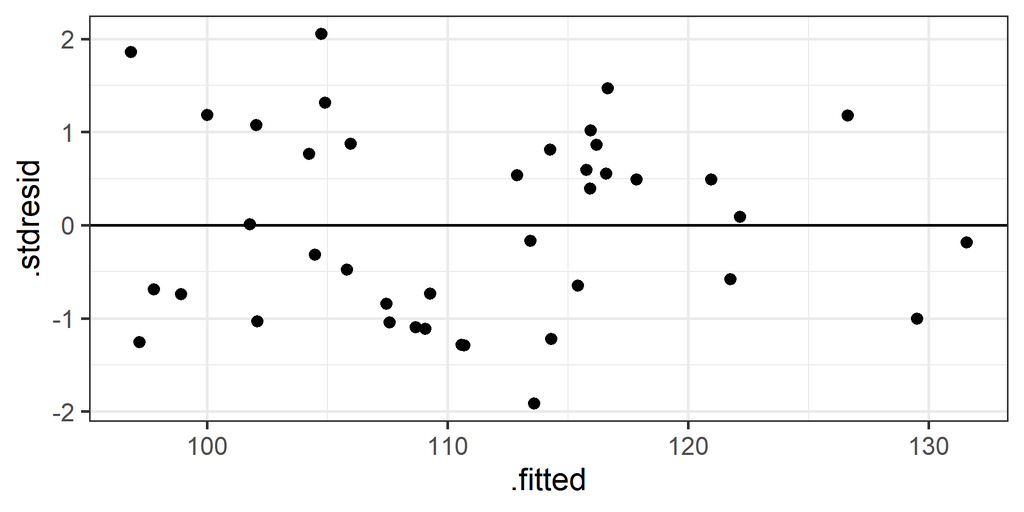

## 1. Линейность связи

## Нелинейность связи видно на графиках остатков

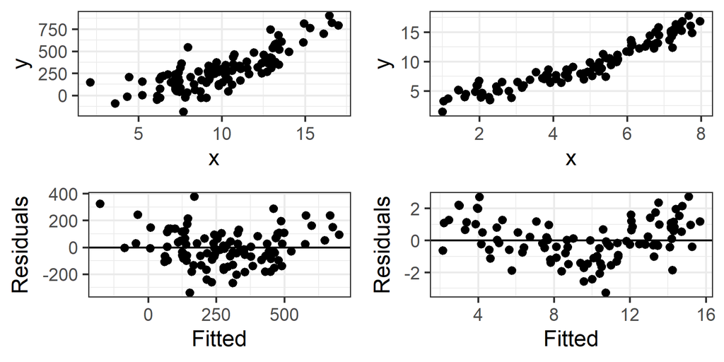

**Проверка на линейность связи**

- График зависимости $y$ от $x$ (и от других переменных, не включенных в модель)
- График остатков от предсказанных значений

## Что делать, если связь нелинейна?

- Добавить неучтенные переменные или взаимодействия;
- Применить линеаризующее преобразование (Осторожно!);
- Применить обобщенную линейную модель с другой функцией связи (GLM);
- Построить аддитивную модель (GAM), если достаточно наблюдений по $x$;
- Построить нелинейную модель, если известна форма зависимости.

## Примеры линеаризующих преобразований

**Логарифмирование**

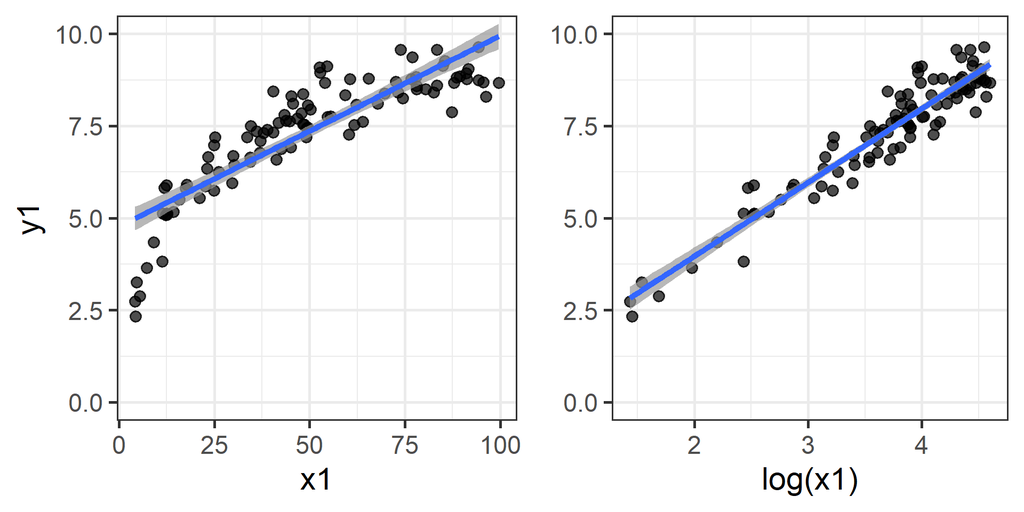

**Возведение в степень**, и т.д.

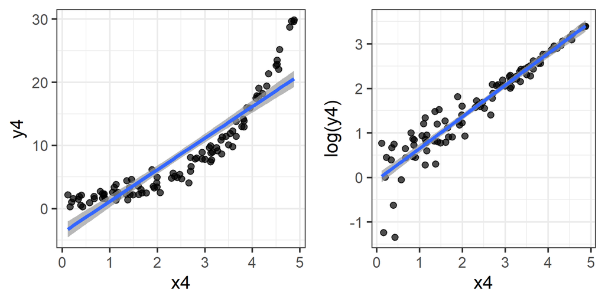

## Не стоит трансформировать отклик!

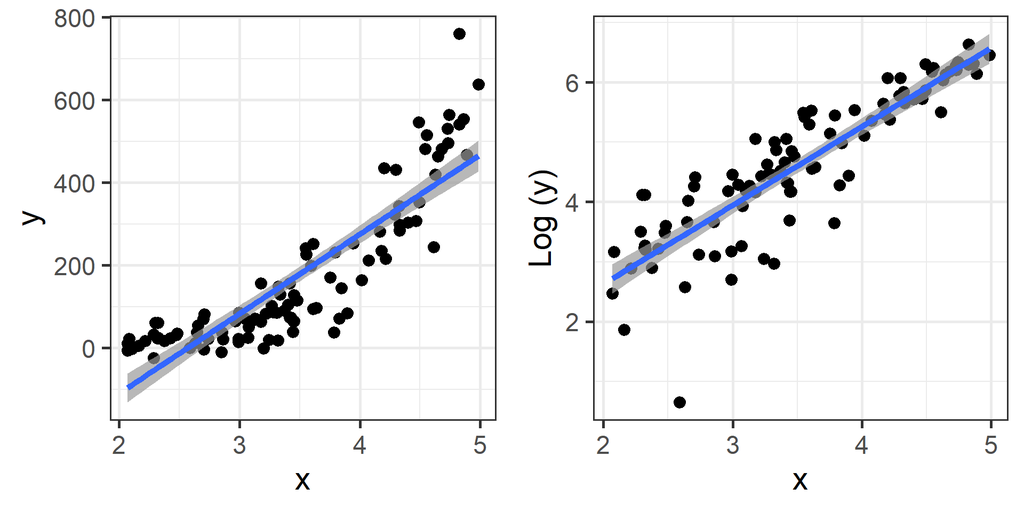

**Осторожно!** Вы рискуете изучить не то, что хотели:

1.При логарифмировании отклика вы будете изучать поведение мат.ожидания логарифма  
$E(log(y_i)) = b_0 + b_1x_{1i} + ... + e_i$.

2.Трансформация отклика не только линеаризует зависимость, но и затронет величину остатков $e$.

Вместо трансформации отклика лучше использовать обобщенную линейную модель с подходящей функцией связи, например:

$log(E(y_i)) = b_0 + b_1x_{1i}+ ... + e_i$

## 2. Независимость

## Каждое значение $y_i$ должно быть независимо от любого другого $y_j$

Это нужно контролировать на этапе планирования сбора материала

- Наиболее частые источники зависимостей:
  - псевдоповторности (повторно измеренные объекты)
  - неучтенные переменные
  - временные автокорреляции (если данные - временной ряд)
  - пространственные автокорреляции (если пробы взяты в разных местах)
  - и т.п.

## Диагностика нарушений независимости

Взаимозависимости можно заметить на графиках остатков

- остатки vs. предсказанные значения
- остатки vs. переменные в модели
- остатки vs. переменные не в модели

## Нарушение независимости: Неучтенная переменная

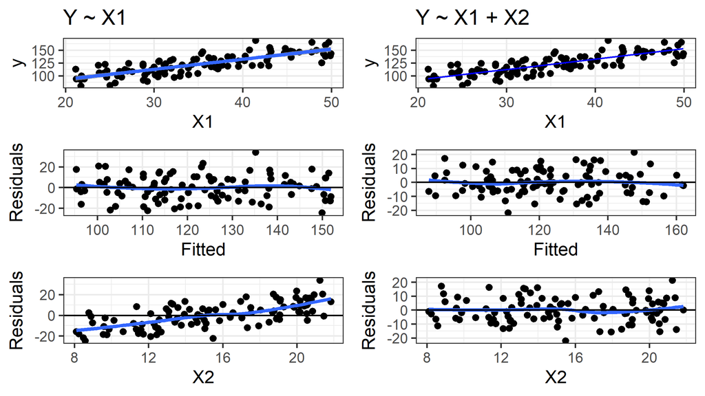

- Слева: Если в модели не учтена переменная $X2$, внешне все нормально, но величина остатков зависит от $X2$
- Справа: Если $X2$ учесть, то зависимость остатков от $X2$ исчезает

## Нарушение независимости: Автокорреляция

В данном случае, наблюдения — это временной ряд  
или ряд наблюдений в пространстве.

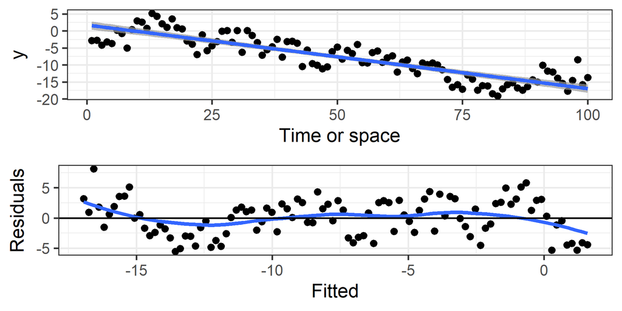

На графиках остатков четко видно, что остатки не являются независимыми. Наблюдения, расположенные на определенном расстоянии друг от друга, имеют остатки похожей величины.

## Чем опасна автокорреляция (и любая другая зависимость наблюдений друг от друга)

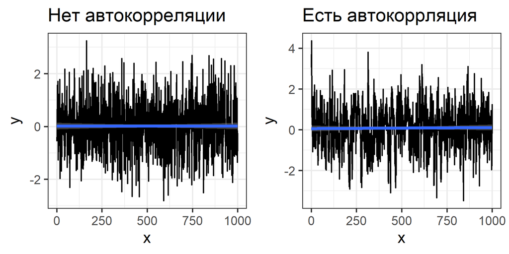

## Чем опасна автокорреляция (и любая другая зависимость наблюдений друг от друга)

Построим 1000 моделей на случайных выборках по 10 последовательных наблюдений

Для простого “шума”, когда **нет автокорреляций** и нет связи между $y$ и $x$ (справедлива $H_0$) частота ошибок составляет

```
[1] 0.048
```

Для **автокоррелированных** данных, при отсутствии связи между $y$ и $x$ (справедлива $H_0$) частота ошибок составляет

```
[1] 0.233
```

Повышается вероятность ошибок I рода.

## Проверка на автокорреляцию

Проверка на автокорреляцию нужна, если данные — это временной ряд, или если известны координаты или время сбора проб. Способы проверки временной автокорреляции (годятся, если наблюдения в ряду расположены через равные интервалы):

- График автокорреляционной функции остатков (ACF-plot) покажет корреляции с разными лагами.

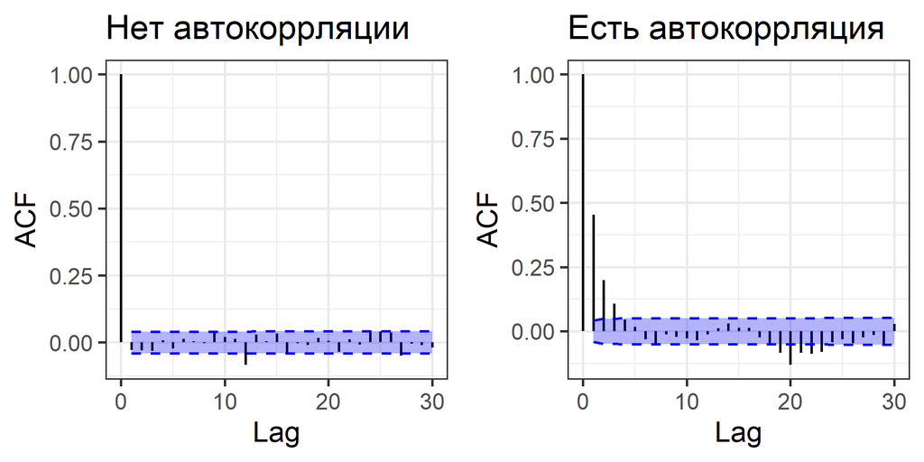

- Критерий Дарбина-Уотсона (значимость автокорреляции 1-го порядка).

Для проверки пространственных автокорреляций: *вариограммы* (большая и сложная тема!)

## Что делать, если у вас нарушено условие независимости значений?

Выбор зависит от обстоятельств. Вот несколько возможных вариантов.

- псевдоповторности
  - избавляемся от псевдоповторностей, вычислив среднее
  - подбираем смешанную модель (модель со случайным фактором)
- неучтенные переменные
  - включаем в модель (если возможно)
- временные автокорреляции
  - моделируем автокорреляцию
  - подбираем модель со случайным фактором
- пространственные автокорреляции
  - моделируем пространственную автокорреляцию
  - делим на пространственные блоки и подбираем модель со случайным фактором (= random effects model, mixed model)

## Проверка условия независимости

### Графики зависимости остатков от предикторов в модели

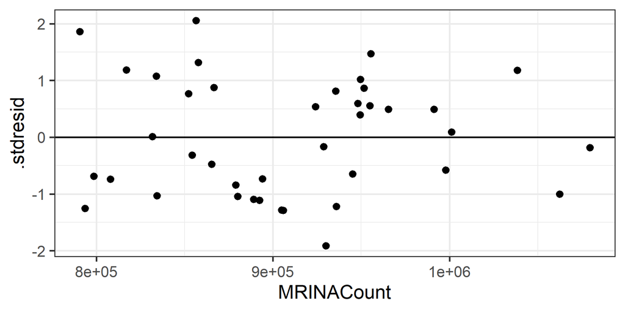

### Графики зависимости остатков от предикторов не в модели

В данном случае их нет

## 3. Нормальное распределение

## 3. Нормальное распределение $y$ (для каждого уровня значений $x$)

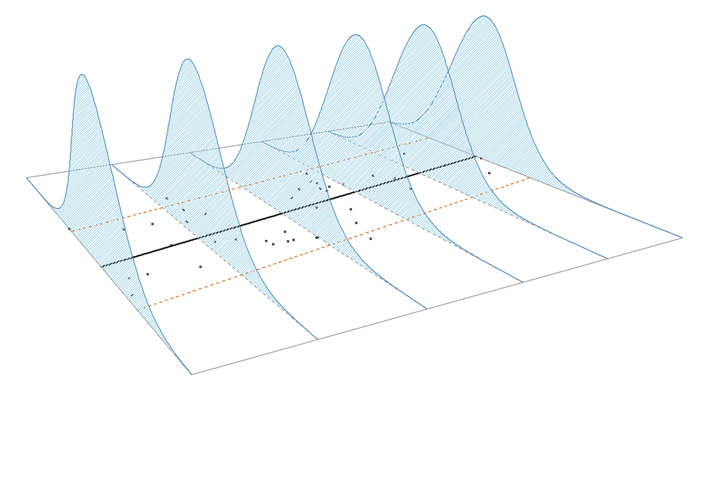

Это условие невозможно проверить “в лоб”, т.к. обычно каждому $x$ соответствует лишь небольшое число $y$

## Проверка нормальности распределения остатков

Если $y$ это нормально распределенная случайная величина

$$y_i \sim N(\mu_{y_i}, \sigma)$$

и мы моделируем ее как

$$y_i = b_0 + b_1x_{1i} + \cdots + e_i$$

то остатки от этой модели — тоже нормально распределенная случайная величина

$$e_i \sim N(0, \sigma)$$

Т.е. выполнение этого условия можно оценить по поведению случайной части модели.

## Проверка нормальности распределения остатков

Есть формальные тесты, но:

- у формальных тестов тоже есть свои условия применимости
- при больших выборках формальные тесты покажут, что значимы даже небольшие отклонения от нормального распределения
- тесты, которые используются в линейной регрессии, устойчивы к небольшим отклонениям от нормального распределения

Лучший способ проверки — квантильный график остатков.

## Квантильный график остатков

По оси Х — квантили теоретического распределения, по оси Y — квантили остатков модели. Если наблюдаемое распределение соответствует теоретическому, то точки должны лечь вдоль прямой по диагонали графика.

Обычные остатки должны подчиняться нормальному распределению $e \sim N(0, \sigma)$

Cтьюдентизированные остатки — t-распределению

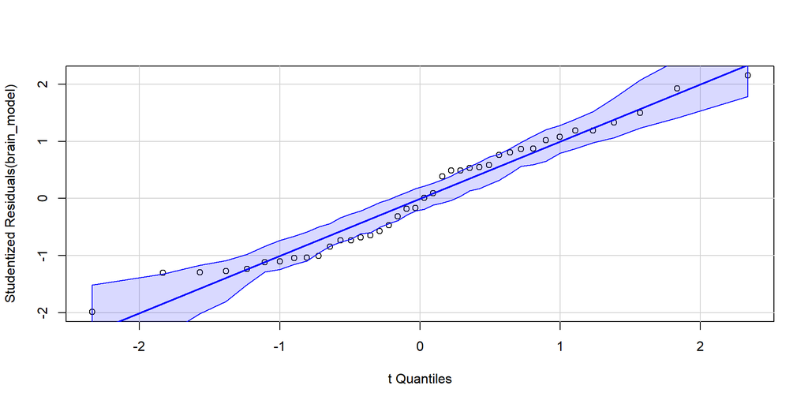

```r
library(car)
qqPlot(brain_model, id = FALSE) # из пакета car
```

## Что делать, если остатки распределены не нормально?

Зависит от причины

- Нелинейная связь?
  - Построить аддитивную модель, GAM (если достаточно наблюдений по $x$)
  - Построить нелинейную модель (если известна форма зависимости)
- Неучтенные переменные?
  - добавляем в модель
- Зависимая переменная распределена по-другому?
  - трансформируем данные (неудобно)
  - подбираем модель с другим распределением остатков (обобщенную линейную модель)

## 4. Постоянство дисперсии

## 4. Постоянство дисперсии (= гомогенность дисперсии, гомоскедастичность)

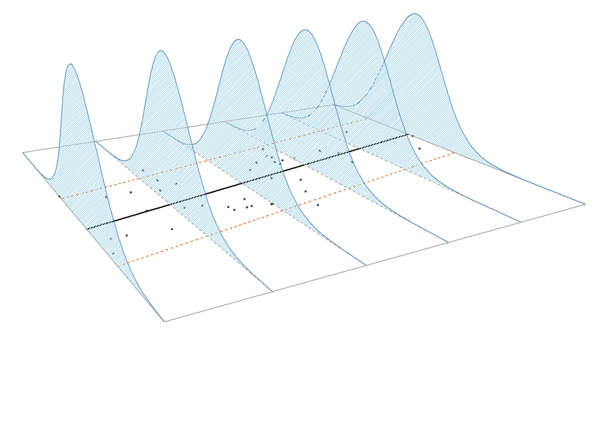

Это самое важное условие, поскольку многие тесты чувствительны к гетероскедастичности.

## Проверка гомогенности дисперсий

Есть формальные тесты (тест Бройша-Пагана, тест Кокрана), но:

- у формальных тестов тоже есть свои условия применимости, и многие сами неустойчивы к гетероскедастичности
- при больших выборках формальные тесты покажут, что значима даже небольшая гетероскедастичность

Лучший способ проверки на гомогенность дисперсий — график остатков от предсказанных значений.

## Проверка гомогенности дисперсий

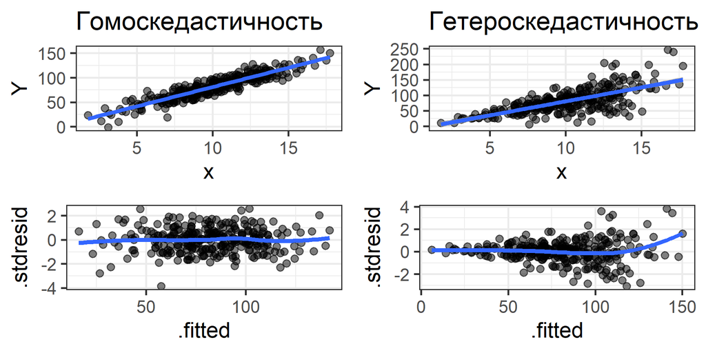

## Чем опасна гетероскедастичность

Создадим две генеральные совокупности, в которых **нет связи** между $y$ и $x$ (справедлива $H_0$)

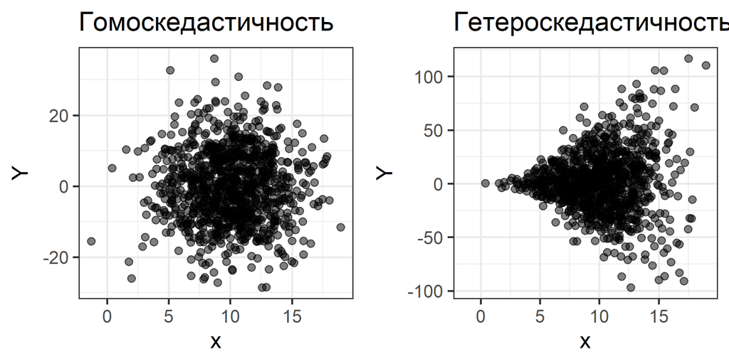

## Чем опасна гетероскедастичность

Возьмем 1000 выборок из этих совокупностей по 10 наблюдений и построим много линейных моделей

- Нет гетероскедастичности и нет связи между $y$ и $x$ (справедлива $H_0$) частота ошибок составляет

```
[1] 0.039
```

- Для совокупности с гетероскедастичностью, при отсутствии связи между $y$ и $x$ (справедлива $H_0$) частота ошибок составляет

```
[1] 0.073
```

Повышается вероятность ошибок I рода.